# Workshop on Experimental Design & Data Analysis

Topic: Generalized Additive Mixed Models

Priscila Lopez-Beltran forcada, Ph.D.

Updated on July, 2023

## In this workshop, we will learn how to analyze *time series data*. to exemplify this, we will be analyzing pupillometry data.

First, what *is* time series data?

Time course refers to the evolution of a measurement *over time*. *Time series* refers to data that form a sequence ordered in time. Therefore, you do a time course experiment and you analyze time series. In our case, pupillometry is considered time series data because data on pupil dilation are collected continuously as the experiment unfolds such that we can obtain a dynamic, continuous measurement of pupil size over a period of time.

The method used to analyze time series data that we will learn in today’s session is called Generalized Additive Mixed Models (GAMMs). A GAMM can be seen as a regression model which is able to model *non-linear patterns* in the data.

For example, we see below that a regression line is unable to capture the non-linear nature of the F2 trajectory.

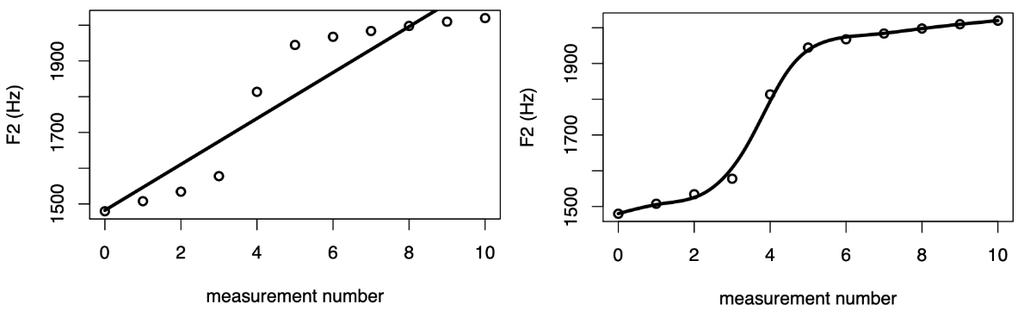

Let us refer to the slopes and intercepts of linear regression models as *parametric terms*. GAMMs differ from traditional linear regression models by allowing *smooth terms* alongside parametric terms. Smooth terms are extremely flexible, that is how they can account for non-linear patterns.

Similar to linear mixed effects models, GAMMs incorporate random effects. These can be random intercepts and random slopes. However, GAMMs also offer a third option: *random smooths.*

Random smooths are similar to random slopes, but they are more flexible than the latter: while random slopes can only capture by-group variation in linear effects, random smooths can also deal with by-group variation in non-linear effects.

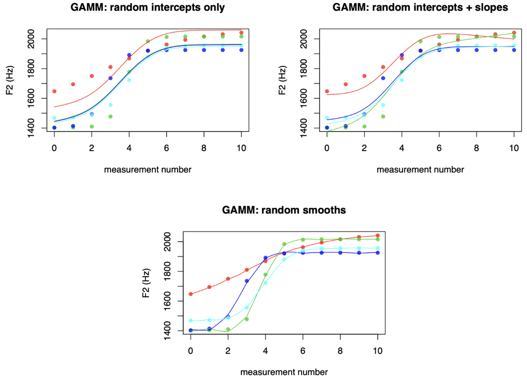

## GAMMs in practice

### The experiment: The Spanish Subjunctive

In Spanish, mood selection is primarily **lexically conditioned**, which entails that a number of verbs (aka *governors*) govern use of the subjunctive and indicative moods A subset of these governors are *non-variable*, meaning that they select the subjunctive 100% of the times (e.g., *querer*). This experiment investigates heritage speakers of Spanish sensitivity to this lexical constraint.

#### Lexical Conditioning Experiment

**1. Condition Non-variable Subjunctive (NVS)** consists of a non-variable governor (in bold) followed by a subordinate verb in the subjunctive (in italics).

**2. Condition Non-variable Indicative (NVI)** is comprised of a non-variable governor (in bold) followed by a subordinate verb in the indicative (in italics).

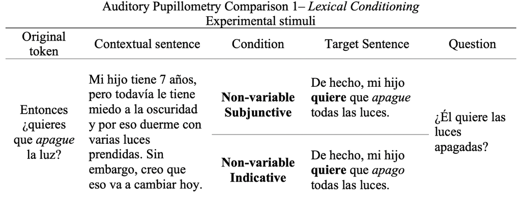

**Hypothesis** Condition NVI will elicit higher pupillary dilation in participants if they are sensitive to the lexical constraint that non-variable governors select the subjunctive categorically (100%).

### Specifying a GAMMs model

The main packages we will be using for GAMMs are `mgcv` to design models and `itsadug` to plot results.

After we load in the the data, we must make sure that *all* categorical variables are factors, otherwise the model won’t run. Finally, we design our model.

We will use the `bam()` function to create our model. This will take approximately 3-5 minutes using a MacBook Pro with Apple M1 Max chip and 32GB of RAM.

```r
model_NV <- bam(corrected_pupil_size ~ condition # fixed effects
             + s(bin, by = condition, k = 20) # smooth for time by condition
             + s(gaze_x, gaze_y) # smooth for gaze position
             + s(bin, participant, bs = 'fs', m = 1, k = 10) # factor smooth for time by participant
             + s(bin, item, bs = 'fs', m = 1, k = 10) # factor smooth for time by item
             , family = "scat" # t-distribution, as assumed in regression
             , data = target_NV # data
             , method = "fREML" # smoothing parameter estimation method fast REML
             , discrete = TRUE) # will help the model converge faster

summary(model_NV)
```

```
##
## Family: Scaled t(3,50.845)
## Link function: identity
##
## Formula:
## corrected_pupil_size ~ condition + s(bin, by = condition, k = 20) +
##     s(gaze_x, gaze_y) + s(bin, participant, bs = "fs", m = 1,
##     k = 10) + s(bin, item, bs = "fs", m = 1, k = 10)
##
## Parametric coefficients:
##              Estimate Std. Error t value Pr(>|t|)
## (Intercept)  -21.8308     6.4202   -3.40 0.000673 ***
## conditionNVS  -7.1275     0.3926  -18.16  < 2e-16 ***
## ---
## Signif. codes:  0 '***' 0.001 '**' 0.01 '*' 0.05 '.' 0.1 ' ' 1
##
## Approximate significance of smooth terms:
##                         edf Ref.df      F  p-value
## s(bin):conditionNVI  11.345  13.69  6.853  < 2e-16 ***
## s(bin):conditionNVS   8.301  10.15  4.207 1.18e-05 ***
## s(gaze_x,gaze_y)     27.439  28.54 72.176  < 2e-16 ***
## s(bin,participant)  288.761 330.00 33.816  < 2e-16 ***
## s(bin,item)         485.315 610.00 28.428  < 2e-16 ***
## ---
## Signif. codes:  0 '***' 0.001 '**' 0.01 '*' 0.05 '.' 0.1 ' ' 1
##
## R-sq.(adj) =  0.139   Deviance explained = 14.4%
## fREML = 2.179e+05  Scale est. = 1         n = 126554
```

### Smooth terms

#### **1. edf**

The edf value is indicative of the amount of non-linearity of the smooth. If the edf value for a certain smooth is (close to) 1, this means that the pattern is (close to) linear, while a value greater than 1 indicates that the pattern is more complex (i.e. non-linear).

#### **2. Ref.df and F**

The Ref.df value is the reference number of degrees of freedom used for hypothesis testing (on the basis of the associated F-value)

### Significance testing - Visualization

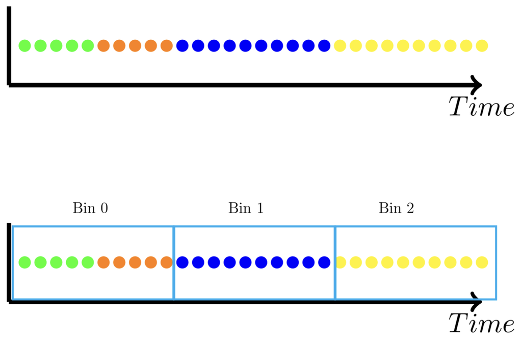

Now, we can visualize the smooths for NVI and NVS. On the Y axis we have pupillary dilation, and on the X axis we have time. We see that NVI elicited higher dilation than NVS starting around time bin 20 (~400 ms into the target period).

```
## Summary:
##  * condition : factor; set to the value(s): NVI, NVS.
##  * bin : numeric predictor; with 30 values ranging from -25.000000 to 150.000000.
##  * gaze_x : numeric predictor; set to the value(s): 971.67.
##  * gaze_y : numeric predictor; set to the value(s): 513.68.
##  * participant : factor; set to the value(s): 44sofsan. (Might be canceled as random effect, check below.)
##  * item : factor; set to the value(s): 54. (Might be canceled as random effect, check below.)
##  * NOTE : The following random effects columns are canceled: s(bin,participant),s(bin,item)
##
```

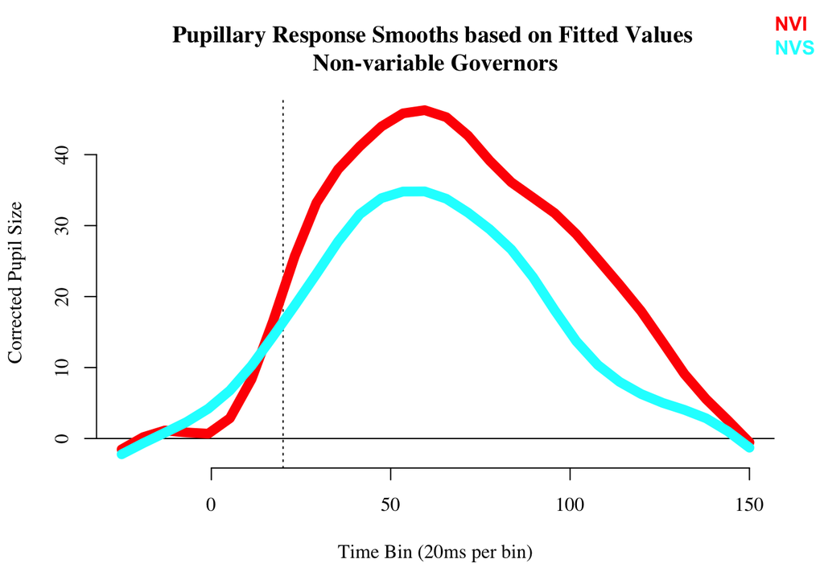

```
## Summary:
##  * bin : numeric predictor; with 100 values ranging from -25.000000 to 150.000000.
##  * gaze_x : numeric predictor; set to the value(s): 971.67.
##  * gaze_y : numeric predictor; set to the value(s): 513.68.
##  * participant : factor; set to the value(s): 44sofsan. (Might be canceled as random effect, check below.)
##  * item : factor; set to the value(s): 54. (Might be canceled as random effect, check below.)
##  * NOTE : The following random effects columns are canceled: s(bin,participant),s(bin,item)
##
```

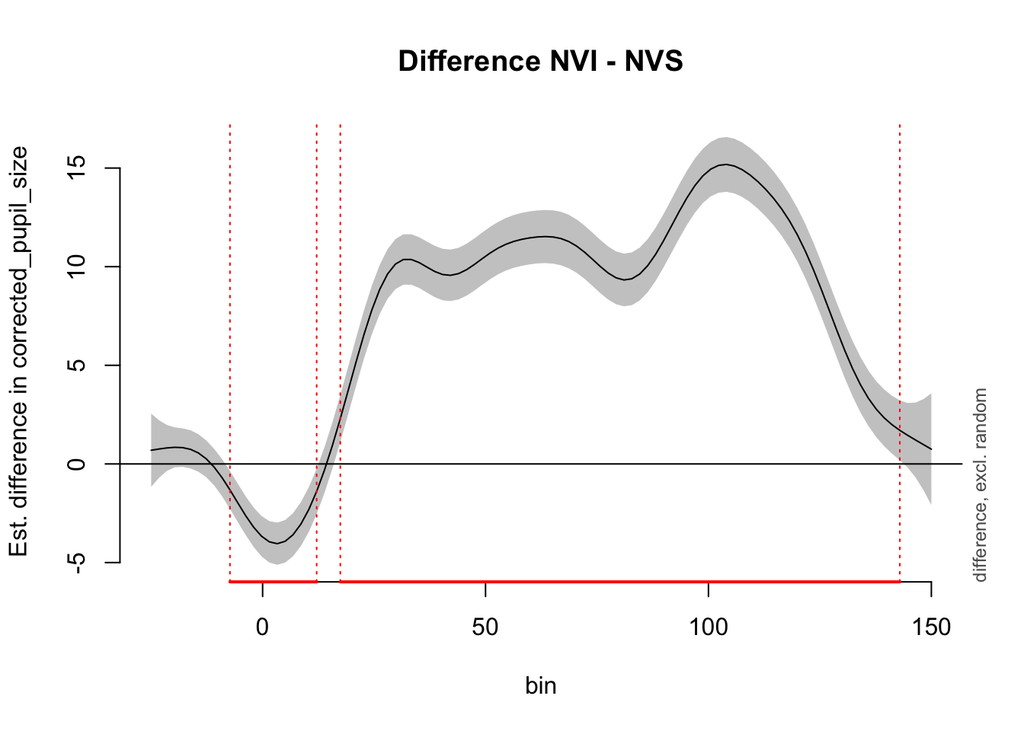

```
##
## bin window(s) of significant difference(s):
##  -7.323232 - 12.121212
##  17.424242 - 142.929293
```

*Note: Other testing for significance: `compareML()`, `plot_diff2()`, `report_stats()`, `wald_gam()`

In all, by interpreting the model and the graphs produced, we can determine that there is a significant difference between conditions which suggests that participants were sensitive to the lexical constraints of non-variable governors for mood selection.

### Significance testing - Binary difference smooths

Another possibility for significance testing is building a model with *binary difference smooths.* These model the difference between the two original smooths. Subsequently, we can assess if this difference smooth is found to be significant *from the model itself*.

To fit this new model, we first have to create a dummy variable. Below, we create the variable *IsInd* (Is Indicative) where the reference value 0 = Subjunctive and 1 = Indicative

```r
target_NV$IsInd <- (target_NV$condition == "NVI")*1
```

Then we specify a model a with smooths which models the difference between the levels of the dummy variable

```r
model_Binary <- bam(corrected_pupil_size ~
                             + s(bin, k = 20) # ref. level = subjunctive
                             + s(bin, by = IsInd, k = 20) # indicative - subjunctive
                             + s(gaze_x, gaze_y)
                             + s(bin, participant, bs = 'fs', m = 1, k = 10)
                             + s(bin, item, bs = 'fs', m = 1, k = 10)
                             , family = "scat"
                             , data = target_NV
                             , method = "fREML"
                             , discrete = TRUE)
summary(model_Binary)
```

```
##
## Family: Scaled t(3,50.86)
## Link function: identity
##
## Formula:
## corrected_pupil_size ~ +s(bin, k = 20) + s(bin, by = IsInd, k = 20) +
##     s(gaze_x, gaze_y) + s(bin, participant, bs = "fs", m = 1,
##     k = 10) + s(bin, item, bs = "fs", m = 1, k = 10)
##
## Parametric coefficients:
##             Estimate Std. Error t value Pr(>|t|)
## (Intercept)   -30.50       6.46  -4.722 2.34e-06 ***
## ---
## Signif. codes:  0 '***' 0.001 '**' 0.01 '*' 0.05 '.' 0.1 ' ' 1
##
## Approximate significance of smooth terms:
##                        edf Ref.df      F  p-value
## s(bin)               9.329  11.25  4.359 4.28e-06 ***
## s(bin):IsInd        11.106  13.33 35.847  < 2e-16 ***
## s(gaze_x,gaze_y)    26.468  27.87 66.366  < 2e-16 ***
## s(bin,participant) 288.375 329.00 33.825  < 2e-16 ***
## s(bin,item)        484.488 609.00 28.498  < 2e-16 ***
## ---
## Signif. codes:  0 '***' 0.001 '**' 0.01 '*' 0.05 '.' 0.1 ' ' 1
##
## R-sq.(adj) =  0.138   Deviance explained = 14.3%
## fREML = 2.1791e+05  Scale est. = 1         n = 126554
```

### Interactions with categorical variables

To explore interactions between categorical variables in GAMMs, first visualize the interaction and then test it.

#### 1. Visualization

We’ll need to create a new **crossover factor** that contains all possible permutations between the two variables of interest. For example if we have:

- Condition
  - NVS
  - NVI
- Regularity
  - Regular
  - Irregular

The crossover factor *CondReg* yields four levels: + NVS Regular + NVS Irregular + NVI Regular + NVI Irregular

We will now create a model with the crossover factor CondReg in order to be able to visualize the smooths for each level. According to the extant literature, our prediction would be that *in the subjunctive, irregular subordinate verbs would be more costly to process*.

Let’s plot the smooths:

```
## Summary:
##  * CondReg : factor; set to the value(s): NVI.irregular, NVI.regular, NVS.irregular, NVS.regular.
##  * bin : numeric predictor; with 30 values ranging from -25.000000 to 150.000000.
##  * gaze_x : numeric predictor; set to the value(s): 971.67.
##  * gaze_y : numeric predictor; set to the value(s): 513.68.
##  * participant : factor; set to the value(s): 44sofsan. (Might be canceled as random effect, check below.)
##  * item : factor; set to the value(s): 54. (Might be canceled as random effect, check below.)
##  * NOTE : The following random effects columns are canceled: s(bin,participant),s(bin,item)
##
```

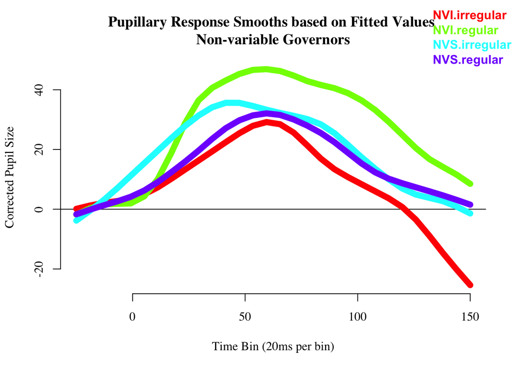

```r
plot_smooth(model_CondReg, view = "bin", plot_all = c("CondReg"),
            rm.ranef = TRUE, rug = FALSE, shade = FALSE, se = 0, lwd = 8,
            main = "Pupillary Response Smooths based on Fitted Values \nNon-variable Governors",
            xlab = "Time Bin (20ms per bin)",
            ylab = "Corrected Pupil Size",
            hide.label = T,
            family = "serif")
```

#### 2. Significance Testing

We will now create a **binary difference smooth model** that will actually enable us to statistically test the interaction between Condition and Regularity.

We will be creating *two* models with different reference levels so that we can explore all levels of the interaction we are interested in.

```r
# Create binary variables by Regularity
target_NV$IsInd <- (target_NV$condition == "NVI")*1 # Ref level subjunctive
target_NV$IsReg <- (target_NV$regularity == "regular")*1 # Ref level irregular
target_NV$IsIndReg <- (target_NV$condition == "NVI" & target_NV$regularity == "regular")*1 # NVS Reg - NVS Irreg
```

First, we create a model with *Subjunctive Irregular as reference level*:

```r
model_Binary_SI <- bam(corrected_pupil_size ~
                                + s(bin, k = 20) # Ref.level: Sub.Irreg
                                + s(bin, by = IsInd, k = 20) # Ind.Irreg - Sub.Irreg
                                + s(bin, by = IsReg, k = 20) # Sub.Reg - Sub.Irreg
                                + s(bin, by = IsIndReg, k = 20) # 4-way interaction
                                + s(gaze_x, gaze_y)
                                + s(bin, participant, bs = 'fs', m = 1, k = 10)
                                + s(bin, item, bs = 'fs', m = 1, k = 10)
                                , family = "scat"
                                , data = target_NV
                                , method = "fREML"
                                , discrete = TRUE)

summary(model_Binary_SI)
```

```
##
## Family: Scaled t(3,50.771)
## Link function: identity
##
## Formula:
## corrected_pupil_size ~ +s(bin, k = 20) + s(bin, by = IsInd, k = 20) +
##     s(bin, by = IsReg, k = 20) + s(bin, by = IsIndReg, k = 20) +
##     s(gaze_x, gaze_y) + s(bin, participant, bs = "fs", m = 1,
##     k = 10) + s(bin, item, bs = "fs", m = 1, k = 10)
##
## Parametric coefficients:
##             Estimate Std. Error t value Pr(>|t|)
## (Intercept)  -31.557      9.944  -3.174  0.00151 **
## ---
## Signif. codes:  0 '***' 0.001 '**' 0.01 '*' 0.05 '.' 0.1 ' ' 1
##
## Approximate significance of smooth terms:
##                        edf  Ref.df      F p-value
## s(bin)               9.280  11.186  4.394 4.6e-06 ***
## s(bin):IsInd         8.564  10.265 15.755 < 2e-16 ***
## s(bin):IsReg         2.032   2.039  0.060   0.951
## s(bin):IsIndReg     10.383  12.442 42.714 < 2e-16 ***
## s(gaze_x,gaze_y)    27.039  28.142 65.690 < 2e-16 ***
## s(bin,participant) 288.115 330.000 33.904 < 2e-16 ***
## s(bin,item)        483.380 609.000 28.239 < 2e-16 ***
## ---
## Signif. codes:  0 '***' 0.001 '**' 0.01 '*' 0.05 '.' 0.1 ' ' 1
##
## R-sq.(adj) =  0.141   Deviance explained = 14.6%
## fREML = 2.1785e+05  Scale est. = 1         n = 126554
```

Second, we create a model with *Indicative Regular as reference level*:

```r
target_NV$IsSub <- (target_NV$condition == "NVS")*1 # indicative as reference level
target_NV$IsIrreg <- (target_NV$regularity == "irregular")*1 # regular as reference level
target_NV$IsSubIrreg <- (target_NV$condition == "NVS" & target_NV$regularity == "irregular")*1 # NVI Irreg - NVI Reg
```

```r
model_Binary_IR <- bam(corrected_pupil_size ~
                                + s(bin, k = 20) # Ref.level: Ind.Reg
                                + s(bin, by = IsSub, k = 20) # Sub.Reg - Ind.Reg
                                + s(bin, by = IsIrreg, k = 20) # Ind.Irreg - Ind.Reg
                                + s(bin, by = IsSubIrreg, k = 20) # 4-way interaction
                                + s(gaze_x, gaze_y)
                                + s(bin, participant, bs = 'fs', m = 1, k = 10)
                                + s(bin, item, bs = 'fs', m = 1, k = 10)
                                , family = "scat"
                                , data = target_NV
                                , method = "fREML"
                                , discrete = TRUE)

summary(model_Binary_IR)
```

```
##
## Family: Scaled t(3,50.769)
## Link function: identity
##
## Formula:
## corrected_pupil_size ~ +s(bin, k = 20) + s(bin, by = IsSub, k = 20) +
##     s(bin, by = IsIrreg, k = 20) + s(bin, by = IsSubIrreg, k = 20) +
##     s(gaze_x, gaze_y) + s(bin, participant, bs = "fs", m = 1,
##     k = 10) + s(bin, item, bs = "fs", m = 1, k = 10)
##
## Parametric coefficients:
##             Estimate Std. Error t value Pr(>|t|)
## (Intercept)  -23.509      7.226  -3.253  0.00114 **
## ---
## Signif. codes:  0 '***' 0.001 '**' 0.01 '*' 0.05 '.' 0.1 ' ' 1
##
## Approximate significance of smooth terms:
##                        edf  Ref.df      F p-value
## s(bin)              11.653  13.722  6.576  <2e-16 ***
## s(bin):IsSub        10.700  12.819 64.982  <2e-16 ***
## s(bin):IsIrreg       2.003   2.003  2.810  0.0601 .
## s(bin):IsSubIrreg    9.779  11.933 44.425  <2e-16 ***
## s(gaze_x,gaze_y)    27.046  28.146 65.856  <2e-16 ***
## s(bin,participant) 287.554 330.000 33.873  <2e-16 ***
## s(bin,item)        483.160 609.000 28.235  <2e-16 ***
## ---
## Signif. codes:  0 '***' 0.001 '**' 0.01 '*' 0.05 '.' 0.1 ' ' 1
##
## R-sq.(adj) =  0.141   Deviance explained = 14.6%
## fREML = 2.1786e+05  Scale est. = 1         n = 126554
```

### Interactions with continuous variables

When fitting a model to examine an interaction with a continuous variable we need **tensor product smooths**, rather than binary difference smooths.

For instance, to explore the effects of Proficiency (Picture Naming RTs) on Condition in GAMMs, the effect needs to be modeled as an interaction with *time*, given that time series data is being analyzed.

Thus, the resulting non-linear interaction accounts for changes in pupil size caused by **proficiency on condition over time.**

#### Visualization

In the case of interactions with continuous variables, visualization is essential to understand the results because it is the only method used to determine significance.

To visualize a two-dimensional pattern such as the effect of proficiency on condition over time, **contour plots** based on the model’s predictions have to be plotted.

The highlighted areas in the plot indicate where there was a significant effect of the independent variable (y-axis) on the dependent variable, and the x-axis shows the time course of the effect.

In addition, to further interpret the results observed, one-dimensional difference smooths can also be plotted in order to assess the magnitude, duration and time-course of the effects.

```
## Summary:
##  * bin : numeric predictor; with 30 values ranging from -25.000000 to 150.000000.
##  * BPN_Sp : numeric predictor; with 30 values ranging from 895.380000 to 1794.150000.
##  * gaze_x : numeric predictor; set to the value(s): 971.67.
##  * gaze_y : numeric predictor; set to the value(s): 513.68.
##  * participant : factor; set to the value(s): 44sofsan. (Might be canceled as random effect, check below.)
##  * item : factor; set to the value(s): 54. (Might be canceled as random effect, check below.)
##  * NOTE : The following random effects columns are canceled: s(bin,participant),s(bin,item)
##
```

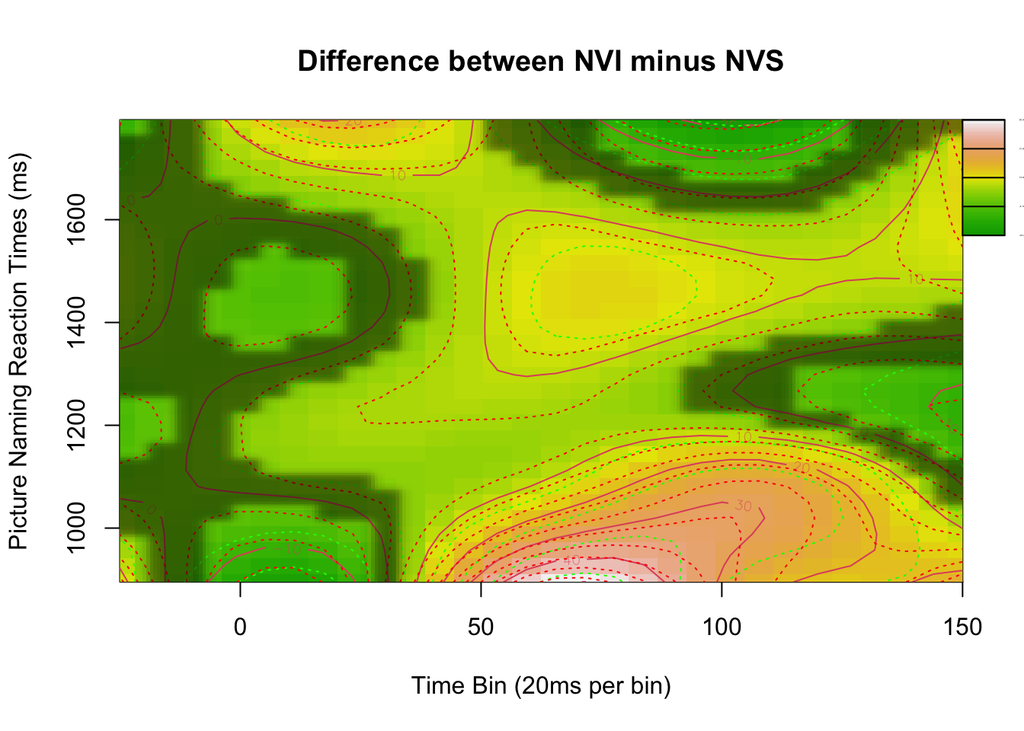

## Resources

- Readings
  - Baayen & Linke (2020). An introduction to the generalized additive model
  - Sóskuthy, M. (2017). Generalised additive mixed models for dynamic analysis in linguistics: a practical introduction
  - Sóskuthy, M. (2021). Evaluating generalised additive mixed modelling strategies for dynamic speech analysis
  - Wieling (2018) Analyzing dynamic phonetic data using generalized additive mixed modeling: A tutorial focusing on articulatory differences between L1 and L2 speakers of English
  - van Rij et al., (2017). Alternative quantitative methods in psycholinguistics: Implications for theory and design
  - van Rij et al., (2019) Analyzing the Time Course of Pupillometric Data
  - Schmidtke (2018) Pupillometry linguistic research: an introduction and review for L2 researchers
  - Sirois & Brisson (2015) Pupillometry